# Catchment area size and concentration

Adam Howes

**Status:** brief note after a discussion with Charlie.

## Concentration considerations

- Consider two types of wastewater concentration:
  1. Removal of excess water
  2. Differential target enrichment

## Nested catchment areas simulation

Is it always preferable to have a larger catchment area? Larger catchment areas are likely to contain more shedding events, but are also likely to process a higher volume of wastewater. Smaller catchment areas are likely to contain less shedding events, and process less volume of wastewater.

One approach to investigating this problem could be to consider nested catchment areas as follows:

```r
library(sf)
```

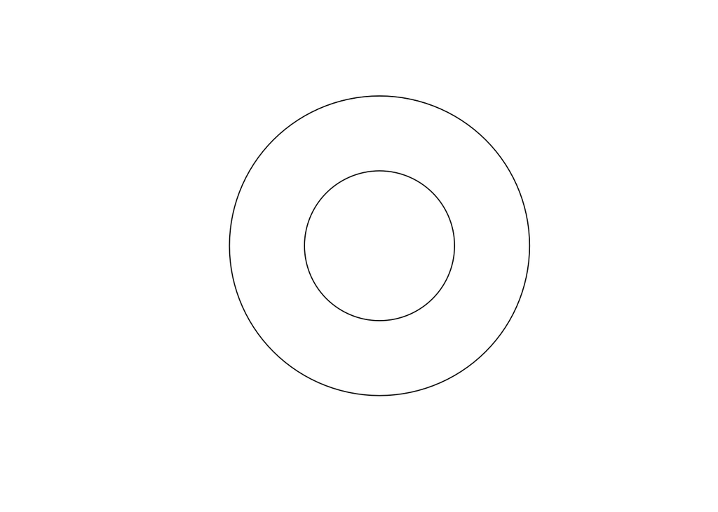

```r
center <- c(0, 0)

r1 <- 1
r2 <- 2

p <- st_point(center)

area1 <- st_buffer(p, dist = r1)
area2 <- st_buffer(p, dist = r2)

geometry <- lapply(list(area1, area2), function(area) list(area) %>% sf::st_multipolygon()) %>%
  sf::st_sfc() %>%
  sf::st_sf()

plot(geometry)
```

- Consider hypothetical catchment areas 1 and 2
  - Catchment area 1 has center 0, 0 and radius 1
  - Catchment area 1 has center 0, 0 and radius 2
- Let time be fixed
- The abundance of target nucleic acid in each catchment area is $A_1$ and $A_2$ with $A_2 \geq A_1$
- The wastewater volume processed in each catchment area is $V_1$ and $V_2$ with $V_2 \geq V_1$
  - Let volume processed be proportional to area such that $V_1 = K\pi$ and $V_2 = 4K \pi$ where $K > 0$ is a constant
- Suppose shedding events $X \sim \text{Poisson}(\lambda)$ are distributed evenly over space
  - Assume each shedding event produces a constant amount of target nucleic acid

```r
K <- 1000

V1 <- K * st_area(area1)
V2 <- K * st_area(area2)

lambda <- 5
X <- rpois(1, 5)
X
```

```
## [1] 6
```

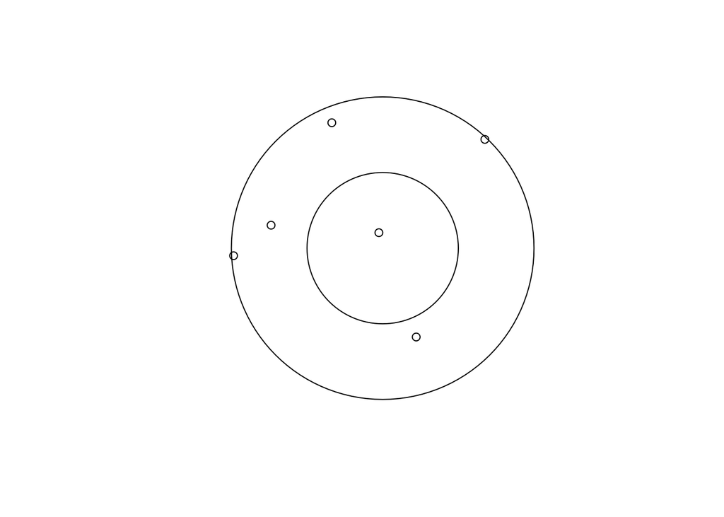

```r
s <- st_sample(area2, size = X, type = "random")

plot(geometry)
plot(s, add = TRUE)
```

```r
s1 <- lengths(st_intersects(area1, s))
s2 <- lengths(st_intersects(area2, s))
```

- We take $K$ to be 1000
- We take $\lambda$ to be 5
- There are 1 shedding events inside area 1 and 6 shedding events inside area 2
- Note that although I visualise this process happening spatially, for the purposes of simulation it isn’t really necessary (it’s just a visual aid)